# Chile Macroeconomic & Sovereign Risk Dashboard

### Prepared by: Christopher Fakhourie

Country & Sovereign Risk Analysis  
Macroeconomic Vulnerability • FX Dynamics • Geopolitical-Economic Transmission

## Executive Summary

Chile remained one of Latin America’s more institutionally credible and macro-financially resilient sovereigns, supported by prudent macroeconomic management, relatively strong policy credibility, and continued access to international capital markets despite elevated external volatility and tighter global financial conditions. Following the inflationary and external-financing pressures observed during the post-pandemic tightening cycle, macroeconomic stabilization conditions gradually improved as inflation moderated, sovereign spreads normalized, reserve accumulation strengthened external liquidity buffers, and current account imbalances began narrowing. The Banco Central de Chile’s restrictive monetary stance played an important role in reinforcing market confidence and anchoring broader macro-financial stabilization conditions during a period characterized by elevated geopolitical uncertainty, externally transmitted inflationary pressures, and global market repricing dynamics.

Despite these improvements, Chile’s sovereign outlook continued to face meaningful medium-term constraints stemming from structurally weaker productivity growth, reduced fiscal maneuverability, and ongoing sensitivity to external financing conditions and global risk sentiment. Although Chile retained comparatively strong institutional buffers relative to many regional peers, tighter global liquidity conditions, elevated financing costs, and post-pandemic fiscal pressures reduced the authorities’ flexibility to respond aggressively to future shocks compared with earlier low-volatility periods. Sovereign spreads and peso dynamics remained particularly sensitive to shifts in external market conditions, foreign portfolio flows, and changes in investor risk appetite, reflecting Chile’s continued exposure to externally transmitted financial volatility despite broader macroeconomic stabilization.

Copper continued to serve as a central stabilizing component within Chile’s sovereign-risk framework due to its importance for export revenues, fiscal performance, and exchange-rate stability. Stronger global demand linked to electrification, energy-transition investment, and AI-related industrial expansion provided important medium-term support for Chile’s external accounts and the Chilean peso, particularly during periods in which interest-rate differentials with the United States remained supportive of capital inflows and currency stabilization. However, the sovereign outlook remained highly sensitive to fluctuations in global commodity demand and external market conditions, particularly given Chile’s dependence on copper exports and exposure to cyclical commodity-price repricing.

Overall, Chile’s sovereign profile appeared characterized by a combination of institutional resilience and persistent external vulnerability. While prudent macroeconomic management, reserve accumulation efforts, and policy credibility continued to support investor confidence and macro-financial stability, structurally weaker growth dynamics, external financing sensitivity, and reduced policy flexibility suggested that Chile’s sovereign outlook would likely remain increasingly dependent on external conditions, commodity-market performance, and the authorities’ ability to sustain long-term productivity and competitiveness improvements beyond commodity-driven growth cycles.

## Dashboard Objectives

- Assess Chile’s sovereign-risk profile through a macro-financial vulnerability framework.
- Evaluate external-account sensitivity, FX volatility, sovereign spreads, reserve accumulation, and fiscal flexibility.
- Link copper, global risk sentiment, and interest-rate differentials to Chile’s sovereign-risk outlook.
- Develop baseline, upside, and downside scenarios for institutional-style sovereign-risk interpretation.

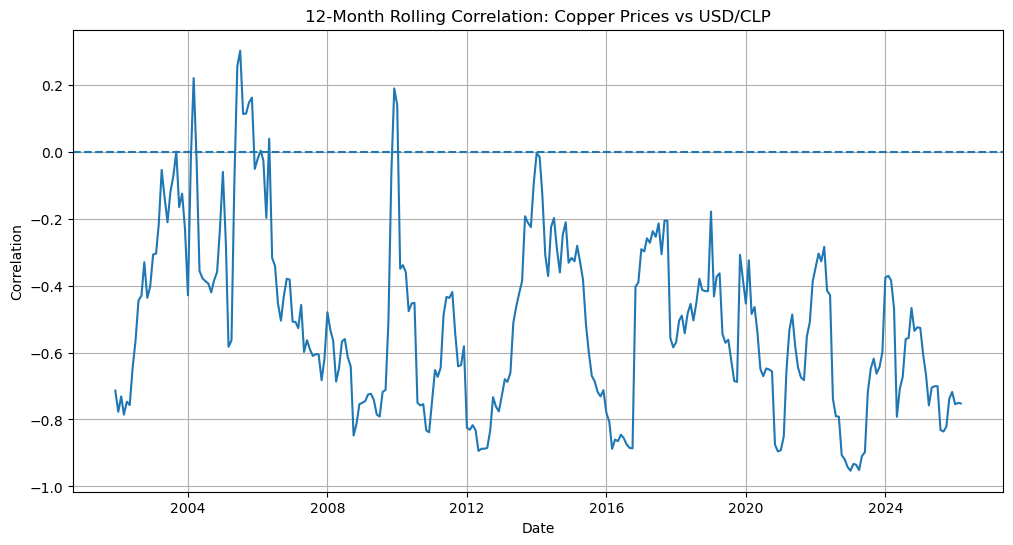

```python
# ============================================
# Plot Rolling Correlation:
# Copper vs USD/CLP
# ============================================

plt.figure(figsize=(12,6))

plt.plot(
    fx_copper_analysis_clean[DATE_COL],
    fx_copper_analysis_clean["rolling_corr_12m"]
)

plt.axhline(
    y=0,
    linestyle="--"
)

plt.title("12-Month Rolling Correlation: Copper Prices vs USD/CLP")
plt.xlabel("Date")
plt.ylabel("Correlation")

plt.show()
```

### Copper, Peso, and External Transmission Commentary

Copper played a central role in Chile’s sovereign-risk profile as a strategic export commodity that supports external balances, fiscal revenues, and the Chilean peso during periods of stronger global demand. Sustained copper demand linked to electrification, energy-transition investment, and AI-related industrial expansion continued to provide an important stabilizing channel for the Chilean economy.

However, the peso remained sensitive to broader global financial conditions, interest-rate differentials with the United States, capital flows, and commodity-price repricing. While stronger copper prices could support CLP appreciation and improve external balances, this stabilizing effect could be offset during periods of unfavorable rate differentials, global risk aversion, or capital outflows. From a sovereign-risk perspective, copper remained both a stabilizer and a source of cyclical exposure.

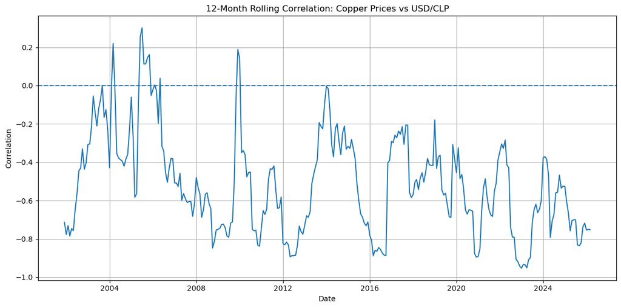

```
Chart saved.
```

```python
# ============================================
# Save Rolling Correlation Chart
# ============================================

plt.figure(figsize=(12,6))

plt.plot(
    fx_copper_analysis_clean[DATE_COL],
    fx_copper_analysis_clean["rolling_corr_12m"]
)

plt.axhline(y=0, linestyle="--")

plt.title("12-Month Rolling Correlation: Copper Prices vs USD/CLP")
plt.xlabel("Date")
plt.ylabel("Correlation")

plt.tight_layout()

plt.savefig(
    CHARTS_DIR / "chile_copper_usdclp_rolling_corr_12m.png",
    dpi=300,
    bbox_inches="tight"
)

plt.show()

print("Chart saved.")
```

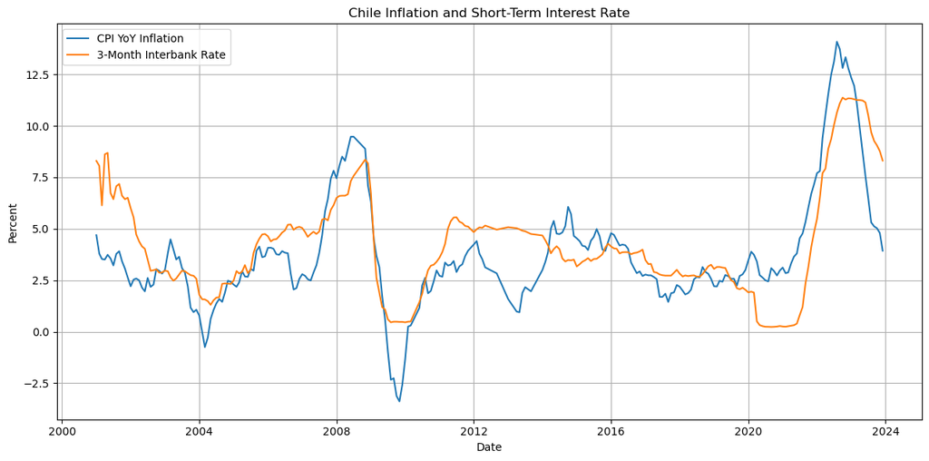

```python
# ============================================
# Plot Chile Inflation vs Short-Term Interest Rate
# ============================================

plt.figure(figsize=(12,6))

plt.plot(
    inflation_policy[DATE_COL],
    inflation_policy["cpi_yoy"],
    label="CPI YoY Inflation"
)

plt.plot(
    inflation_policy[DATE_COL],
    inflation_policy["short_rate"],
    label="3-Month Interbank Rate"
)

plt.title("Chile Inflation and Short-Term Interest Rate")
plt.xlabel("Date")
plt.ylabel("Percent")

plt.legend()
plt.tight_layout()
plt.show()
```

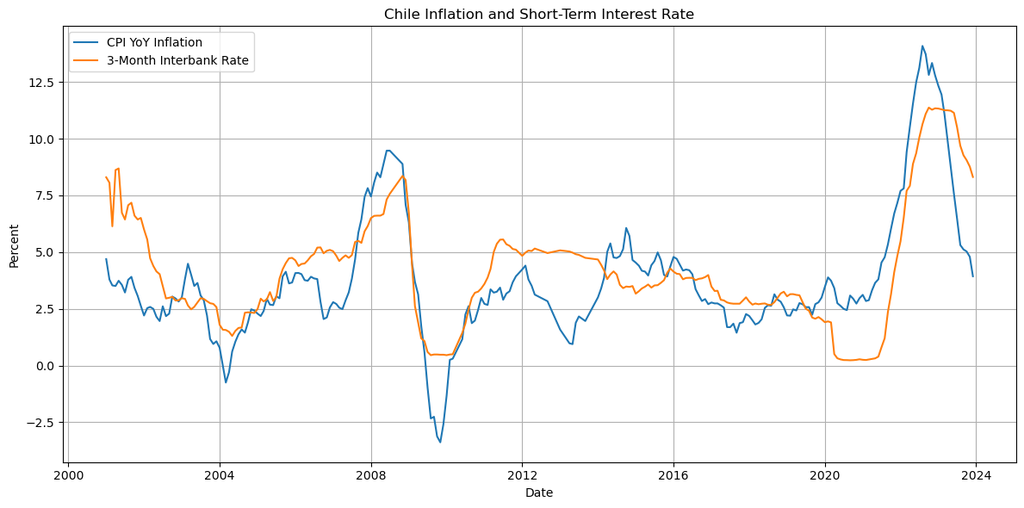

```
Inflation-policy chart saved.
```

```python
plt.figure(figsize=(12,6))

plt.plot(inflation_policy[DATE_COL], inflation_policy["cpi_yoy"], label="CPI YoY Inflation")
plt.plot(inflation_policy[DATE_COL], inflation_policy["short_rate"], label="3-Month Interbank Rate")

plt.title("Chile Inflation and Short-Term Interest Rate")
plt.xlabel("Date")
plt.ylabel("Percent")
plt.legend()
plt.tight_layout()

plt.savefig(
    CHARTS_DIR / "chile_inflation_short_rate.png",
    dpi=300,
    bbox_inches="tight"
)

plt.show()

print("Inflation-policy chart saved.")
```

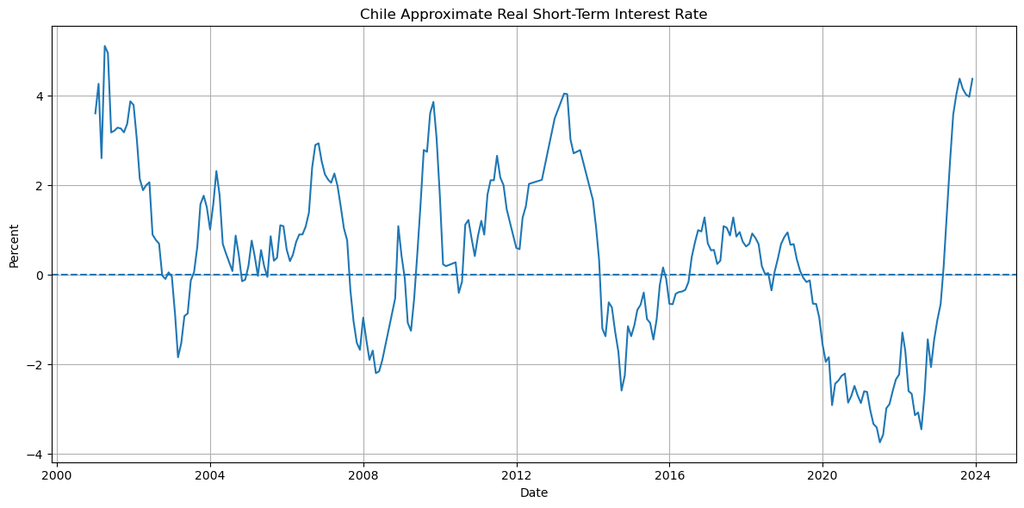

```python
# ============================================
# Plot Chile Real Short Rate
# ============================================

plt.figure(figsize=(12,6))

plt.plot(
    inflation_policy[DATE_COL],
    inflation_policy["real_short_rate"]
)

plt.axhline(
    y=0,
    linestyle="--"
)

plt.title("Chile Approximate Real Short-Term Interest Rate")
plt.xlabel("Date")
plt.ylabel("Percent")

plt.tight_layout()
plt.show()
```

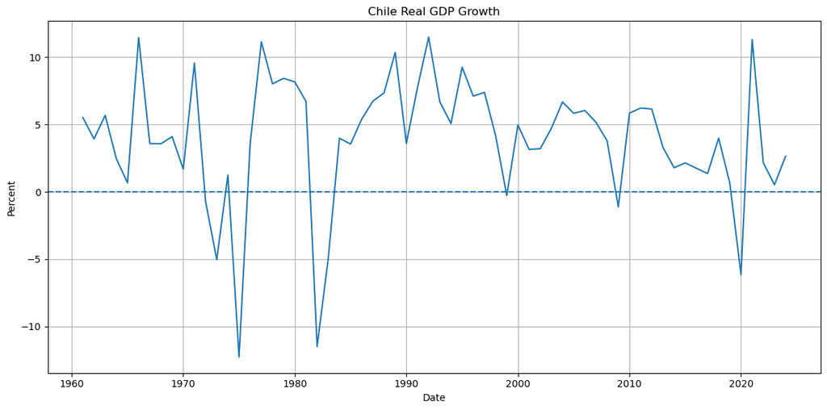

```python
# ============================================
# Plot Chile GDP Growth
# ============================================

plt.figure(figsize=(12,6))

plt.plot(
    gdp_growth_clean[DATE_COL],
    gdp_growth_clean["gdp_growth"]
)

plt.axhline(
    y=0,
    linestyle="--"
)

plt.title("Chile Real GDP Growth")
plt.xlabel("Date")
plt.ylabel("Percent")

plt.tight_layout()
plt.show()
```

### Structural Growth and Productivity Commentary

Chile’s long-term sovereign outlook remained supported by relatively strong institutional credibility, prudent macroeconomic management, and continued access to international capital markets. However, structurally weaker productivity growth, declining investment dynamism, and persistent competitiveness constraints increasingly limited the economy’s medium-term growth potential despite ongoing stabilization efforts.

OECD and IMF assessments consistently highlighted concerns surrounding slower trend productivity, labor-market rigidities, investment bottlenecks, and uneven reform execution, suggesting that macroeconomic stabilization alone may not be sufficient to restore stronger long-run growth momentum. These structural constraints remained particularly important from a sovereign-risk perspective, as weaker potential growth could gradually reduce fiscal flexibility, constrain revenue generation, and increase sensitivity to external financing conditions and commodity-price volatility over time.

While Chile continued to benefit from institutional resilience and strategic copper exposure linked to global electrification and AI-related demand dynamics, the economy’s longer-term trajectory increasingly depended on its ability to improve productivity, attract sustained investment, and strengthen structural competitiveness beyond commodity-driven growth cycles.

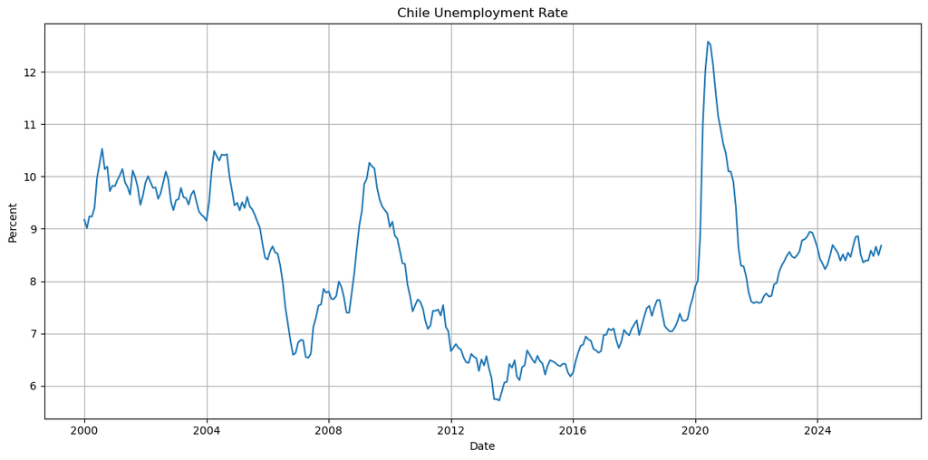

```python
# ============================================
# Plot Chile Unemployment Rate
# ============================================

plt.figure(figsize=(12,6))

plt.plot(
    unemployment_clean[DATE_COL],
    unemployment_clean["unemployment_rate"]
)

plt.title("Chile Unemployment Rate")
plt.xlabel("Date")
plt.ylabel("Percent")

plt.tight_layout()
plt.show()
```

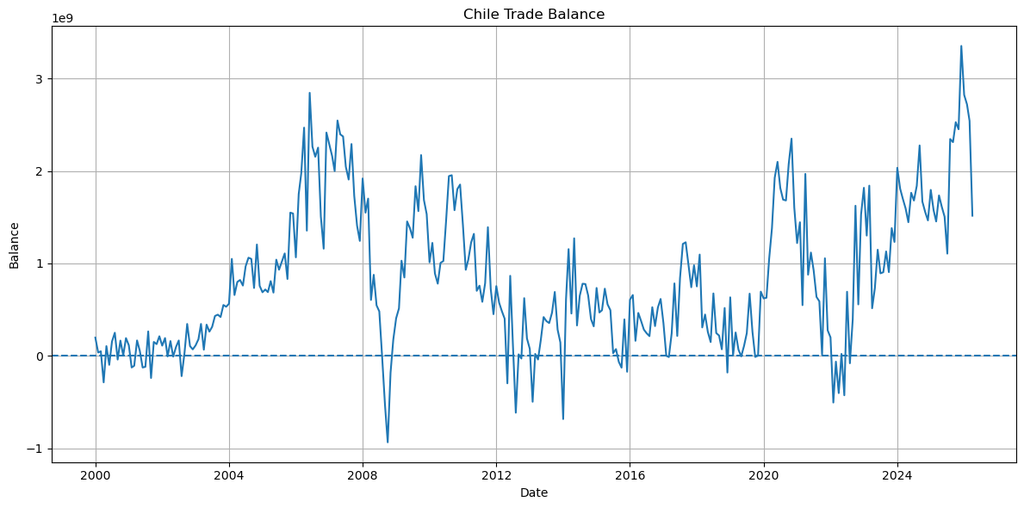

```python
# ============================================
# Plot Chile Trade Balance
# ============================================

plt.figure(figsize=(12,6))

plt.plot(
    trade_balance_clean[DATE_COL],
    trade_balance_clean["trade_balance"]
)

plt.axhline(
    y=0,
    linestyle="--"
)

plt.title("Chile Trade Balance")
plt.xlabel("Date")
plt.ylabel("Balance")

plt.tight_layout()
plt.show()
```

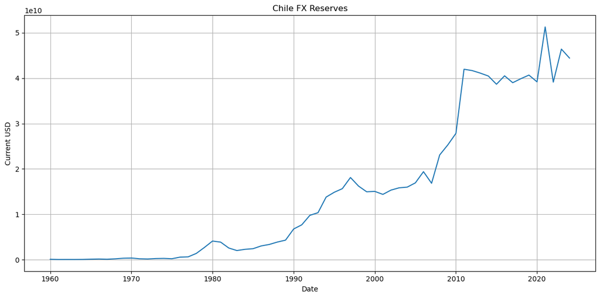

```python
# ============================================
# Plot Chile FX Reserves
# ============================================

plt.figure(figsize=(12,6))

plt.plot(
    fx_reserves_clean[DATE_COL],
    fx_reserves_clean["fx_reserves"]
)

plt.title("Chile FX Reserves")
plt.xlabel("Date")
plt.ylabel("Current USD")

plt.tight_layout()
plt.show()
```

### Reserve Accumulation and External Liquidity Commentary

Chile’s international reserve position improved during the recent period as the Banco Central de Chile continued implementing a reserve accumulation program aimed at strengthening external liquidity buffers and reinforcing macro-financial resilience. The increase in reserve assets suggested a prudent and proactive policy approach amid ongoing global financial uncertainty, tighter external financing conditions, and continued sensitivity to exchange-rate volatility.

Higher reserve holdings also enhanced Chile’s capacity to absorb external shocks, support market confidence, and mitigate periods of peso instability during episodes of global risk repricing or commodity-market volatility. From a sovereign-risk perspective, the continued accumulation of international reserves reinforced Chile’s broader institutional credibility and reflected an effort to preserve external stability despite persistent exposure to foreign portfolio flows, commodity-price fluctuations, and externally transmitted financial stress.

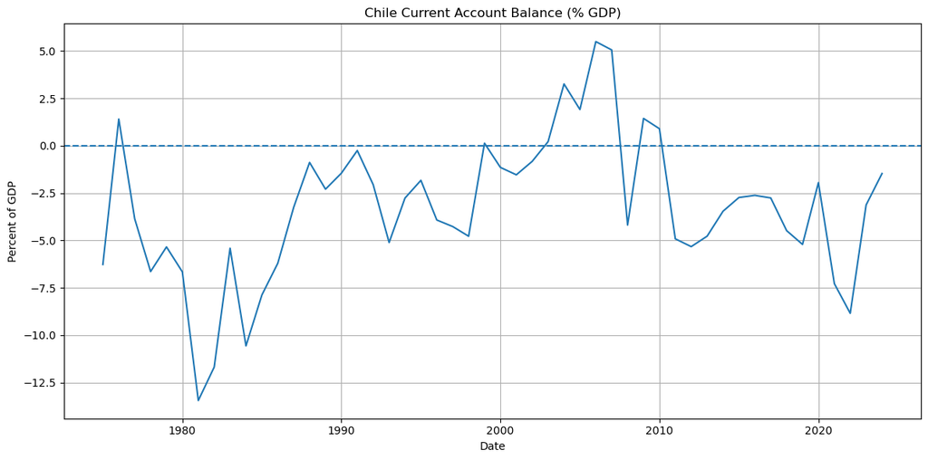

```python
# ============================================
# Plot Chile Current Account (% GDP)
# ============================================

plt.figure(figsize=(12,6))

plt.plot(
    current_account_clean[DATE_COL],
    current_account_clean["current_account_gdp"]
)

plt.axhline(
    y=0,
    linestyle="--"
)

plt.title("Chile Current Account Balance (% GDP)")
plt.xlabel("Date")
plt.ylabel("Percent of GDP")

plt.tight_layout()
plt.show()
```

### Current Account and External Balance Commentary

Chile’s current account deficit showed signs of gradual improvement following the sharp external imbalances observed during the post-pandemic period, supported by moderating import demand, tighter domestic financial conditions, and stronger copper export revenues. Higher copper prices continued to provide an important external stabilizing mechanism for the Chilean economy by supporting export earnings and contributing to peso stabilization during periods of favorable global commodity demand.

However, despite the expected narrowing in the external deficit, Chile remained vulnerable to fluctuations in the peso and broader external financing conditions, reflecting the economy’s continued sensitivity to commodity-price volatility, foreign portfolio flows, and shifts in global risk sentiment. Structurally weaker growth dynamics and external demand uncertainty also suggested that improvements in the current account position could remain vulnerable to future external shocks and cyclical commodity repricing.

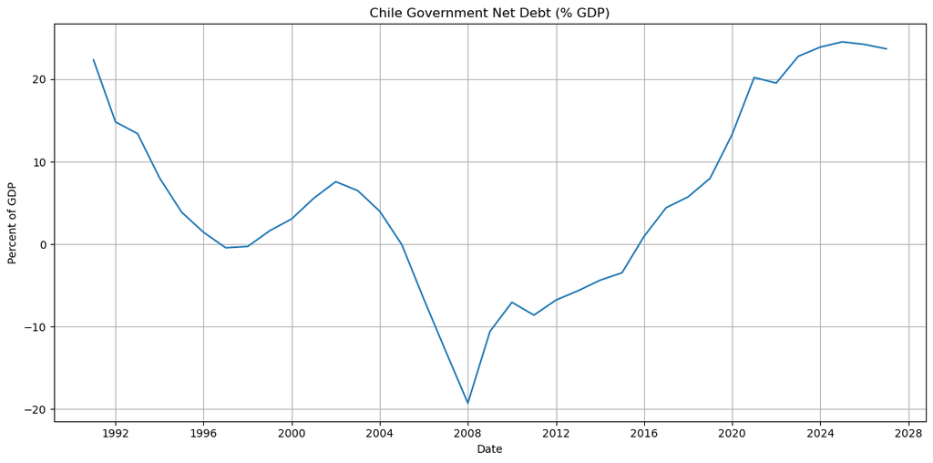

```python
# ============================================
# Plot Chile Government Net Debt (% GDP)
# ============================================

plt.figure(figsize=(12,6))

plt.plot(
    debt_gdp_clean[DATE_COL],
    debt_gdp_clean["debt_gdp"]
)

plt.title("Chile Government Net Debt (% GDP)")
plt.xlabel("Date")
plt.ylabel("Percent of GDP")

plt.tight_layout()
plt.show()
```

### Fiscal Position and Debt Dynamics Commentary

Chile’s fiscal position remained comparatively resilient relative to many regional peers, supported by prudent macroeconomic management, institutional credibility, and historically moderate sovereign debt levels. However, the country’s fiscal flexibility appeared more constrained than in previous periods as tighter monetary conditions, elevated financing costs, and rising post-pandemic fiscal pressures reduced the government’s room to maneuver during future external shocks.

Efforts to stabilize debt dynamics through fiscal consolidation and restrictive monetary policy helped reinforce market confidence and contributed to broader macro-financial normalization, although these measures also reflected a more challenging external environment characterized by slower growth, tighter global liquidity conditions, and greater sensitivity to external financing volatility. From a sovereign-risk perspective, Chile continued to retain important fiscal and institutional buffers, but reduced policy space suggested that future shocks could place greater pressure on fiscal adjustment capacity compared with earlier low-volatility periods.

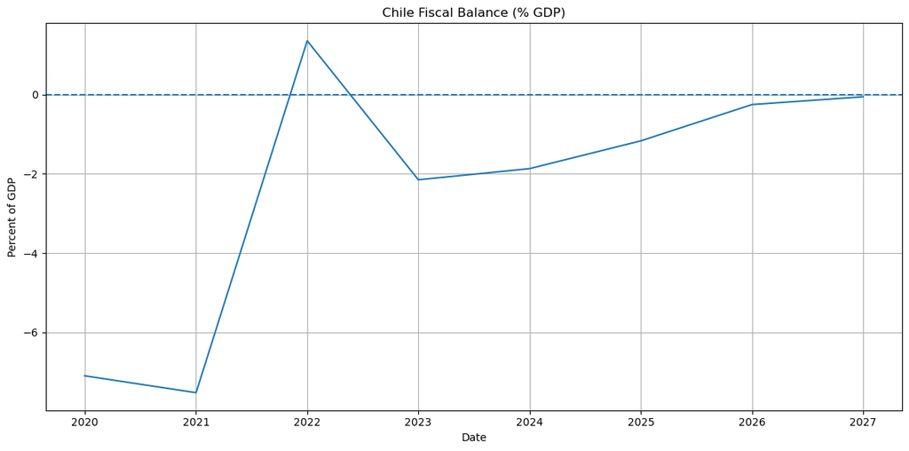

```python
# ============================================
# Plot Chile Fiscal Balance (% GDP)
# ============================================

plt.figure(figsize=(12,6))

plt.plot(
    fiscal_balance_clean[DATE_COL],
    fiscal_balance_clean["fiscal_balance_gdp"]
)

plt.axhline(
    y=0,
    linestyle="--"
)

plt.title("Chile Fiscal Balance (% GDP)")
plt.xlabel("Date")
plt.ylabel("Percent of GDP")

plt.tight_layout()
plt.show()
```

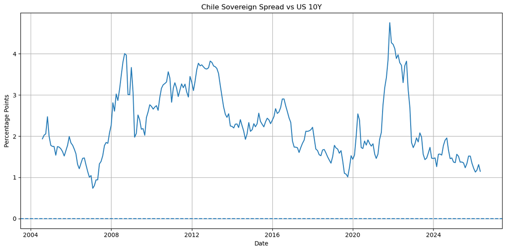

```python
# ============================================
# Plot Chile Sovereign Spread
# ============================================

plt.figure(figsize=(12,6))

plt.plot(
    spread_df[DATE_COL],
    spread_df["sovereign_spread"]
)

plt.axhline(
    y=0,
    linestyle="--"
)

plt.title("Chile Sovereign Spread vs US 10Y")
plt.xlabel("Date")
plt.ylabel("Percentage Points")

plt.tight_layout()
plt.show()
```

### Sovereign Spread Commentary

However, despite the normalization observed through 2023–2024, Chile’s sovereign spreads remained sensitive to shifts in global risk sentiment and external repricing dynamics, partly reflecting the economy’s exposure to foreign portfolio flows, tighter international financing conditions, and increased sensitivity to externally transmitted market volatility.

**Sovereign implication:** Chile’s spread normalization supports the view of a credible and resilient sovereign, but not an insulated one. Market pricing remains closely linked to global liquidity, external financing conditions, and risk sentiment.

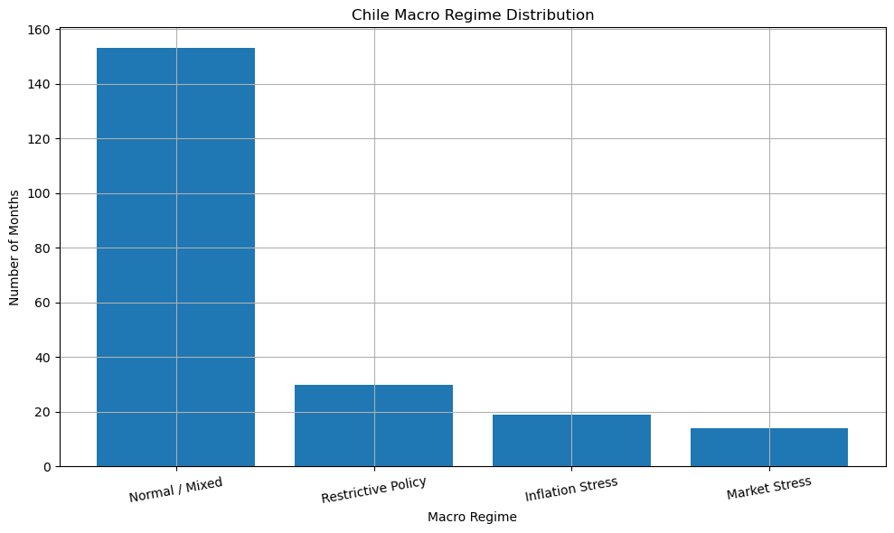

```python
# ============================================
# Plot Macro Regime Distribution
# ============================================

plt.figure(figsize=(10,6))

plt.bar(
    regime_counts["Macro_Regime"],
    regime_counts["Months"]
)

plt.title("Chile Macro Regime Distribution")
plt.xlabel("Macro Regime")
plt.ylabel("Number of Months")

plt.xticks(rotation=10)

plt.tight_layout()
plt.show()
```

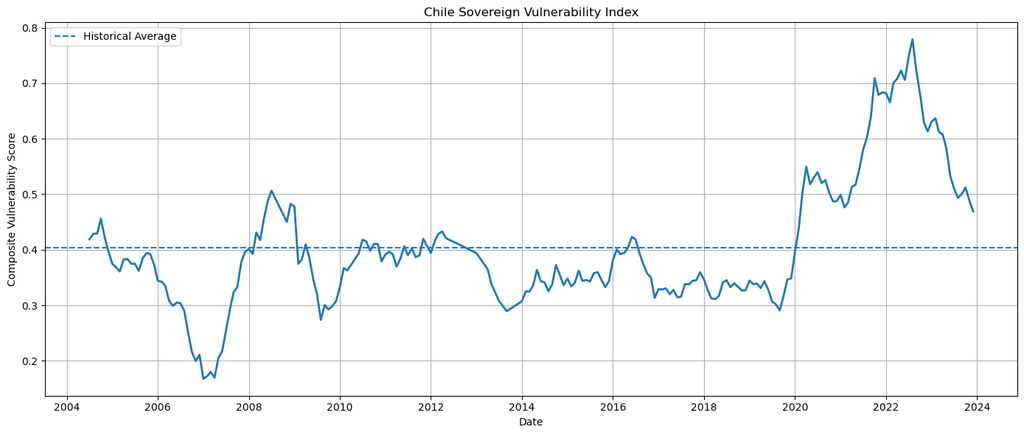

```python
# ============================================
# Improved Sovereign Vulnerability Index Plot
# ============================================

plt.figure(figsize=(14,6))

plt.plot(
    vulnerability_clean["month"].dt.to_timestamp(),
    vulnerability_clean["sovereign_vulnerability_index"],
    linewidth=2
)

plt.axhline(
    y=vulnerability_clean[
        "sovereign_vulnerability_index"
    ].mean(),
    linestyle="--",
    label="Historical Average"
)

plt.title(
    "Chile Sovereign Vulnerability Index"
)

plt.xlabel("Date")

plt.ylabel("Composite Vulnerability Score")

# Show cleaner yearly ticks
plt.gca().xaxis.set_major_locator(
    mdates.YearLocator(2)
)

plt.gca().xaxis.set_major_formatter(
    mdates.DateFormatter('%Y')
)

plt.legend()

plt.tight_layout()

plt.show()
```

### Sovereign Vulnerability Index Commentary

Chile’s Sovereign Vulnerability Index improved materially following the inflation and tightening-cycle shock observed during 2021–2022, reflecting easing inflationary pressures, restrictive real policy rates, and improving macro-financial stabilization conditions. However, the index remained above the lower-volatility equilibrium observed during earlier periods, suggesting that external financing sensitivity, geopolitical uncertainty, and structurally weaker growth dynamics continued to expose the economy to moderate residual vulnerability despite ongoing fiscal consolidation and reform efforts.

**Sovereign implication:** Chile’s macro-financial environment has stabilized, but the post-shock equilibrium remains more externally sensitive than the pre-pandemic baseline.

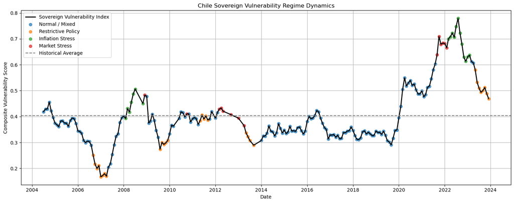

```python
# ============================================
# Dynamic Regime Visualization
# ============================================

plt.figure(figsize=(15,6))

# Plot vulnerability index
plt.plot(
    vulnerability_clean["month"].dt.to_timestamp(),
    vulnerability_clean["sovereign_vulnerability_index"],
    linewidth=2,
    color="black",
    label="Sovereign Vulnerability Index"
)

# Shade regimes
for regime in regime_colors.keys():

    subset = regime_df[
        regime_df["macro_regime"] == regime
    ]

    plt.scatter(
        subset["month"].dt.to_timestamp(),
        vulnerability_clean.loc[
            vulnerability_clean["month"].isin(subset["month"]),
            "sovereign_vulnerability_index"
        ],
        label=regime,
        alpha=0.7
    )

plt.axhline(
    y=vulnerability_clean[
        "sovereign_vulnerability_index"
    ].mean(),
    linestyle="--",
    color="gray",
    label="Historical Average"
)

plt.title(
    "Chile Sovereign Vulnerability Regime Dynamics"
)

plt.xlabel("Date")

plt.ylabel("Composite Vulnerability Score")

plt.gca().xaxis.set_major_locator(
    mdates.YearLocator(2)
)

plt.gca().xaxis.set_major_formatter(
    mdates.DateFormatter('%Y')
)

plt.legend()

plt.tight_layout()

plt.show()
```

# Scenario Framework

## Baseline Scenario — Highest Probability

Chile’s baseline sovereign outlook remained supported by relatively strong institutional credibility, prudent macroeconomic management, restrictive monetary policy credibility, and continued demand for copper exports linked to global electrification and AI-related industrial expansion. Gradual improvement in the current account balance, reserve accumulation efforts, and moderating inflationary pressures suggested that macro-financial stabilization conditions were continuing to improve following the volatility observed during the post-pandemic and global tightening-cycle periods.

However, structurally weaker productivity growth, reduced fiscal maneuverability, and continued sensitivity to external financing conditions limited the economy’s medium-term flexibility despite broader stabilization progress. While favorable interest-rate differentials relative to the United States and stronger copper demand could continue supporting the Chilean peso and investor confidence, the sovereign outlook remained vulnerable to shifts in global risk sentiment and externally transmitted financial volatility.

## Upside Scenario

Chile’s sovereign outlook could strengthen further under a scenario characterized by sustained global copper demand, stronger Chinese industrial activity, easing global financial conditions, and improved domestic investment dynamics. Higher copper prices and stronger export revenues would likely support further appreciation of the Chilean peso, strengthen external balances, and reinforce fiscal revenues, particularly if interest-rate differentials with the United States remained supportive of capital inflows and currency stabilization.

Continued reserve accumulation, successful reform execution, and improving productivity conditions could also contribute to stronger medium-term growth expectations and narrower sovereign spreads. Under this scenario, Chile’s institutional credibility and prudent macroeconomic framework would likely reinforce investor confidence and improve the sovereign’s resilience to external shocks.

## Downside Scenario

Chile’s sovereign outlook remained exposed to downside risks stemming from weaker global growth conditions, declining copper demand, tighter external financing conditions, and renewed episodes of global market repricing. A deterioration in Chinese industrial demand or a prolonged period of elevated global interest rates could place downward pressure on copper prices, weaken the Chilean peso, and widen the current account deficit through reduced export earnings and increased external financing stress.

Reduced fiscal and monetary policy flexibility compared with earlier low-volatility periods could also constrain the authorities’ ability to respond aggressively to future shocks. Under this scenario, sovereign spreads could widen further amid rising investor risk aversion, increased capital outflows, and heightened sensitivity to external portfolio-flow volatility despite Chile’s relatively strong institutional framework and reserve position.

# Appendix A — Technical Code and Methodology

## Data Sources

- Banco Central de Chile
- IMF Article IV Consultation
- IMF World Economic Outlook
- OECD Economic Survey of Chile
- World Bank Commodity Outlook
- FRED Database

## Methodological Notes

This dashboard uses publicly available macroeconomic, financial-market, and institutional data to assess Chile’s sovereign-risk profile. The analysis combines descriptive macroeconomic indicators, market-sensitive variables, external-account measures, and scenario-based interpretation. The Sovereign Vulnerability Index is constructed as an analytical composite of normalized macro-financial indicators and is intended to support directional sovereign-risk interpretation rather than provide a formal credit rating.

## Analytical Disclaimer

This dashboard is intended for educational and analytical purposes only and does not constitute investment advice, credit advice, or a formal sovereign rating opinion.

### Technical Code Cell 1

```python
# ============================================
# CHILE SOVEREIGN RISK DASHBOARD
# Setup & Data Source Framework
# ============================================

# Core libraries
import pandas as pd
import numpy as np
import matplotlib.pyplot as plt
import matplotlib.dates as mdates

# Display settings
pd.set_option("display.max_columns", 50)
pd.set_option("display.width", 120)

# Chart defaults
plt.rcParams["figure.figsize"] = (12, 6)
plt.rcParams["axes.grid"] = True

# --------------------------------------------
# Source Framework
# --------------------------------------------

sources = {
    "Banco Central de Chile": [
        "Policy rate",
        "USD/CLP exchange rate",
        "FX reserves",
        "Balance of payments",
        "National accounts"
    ],
    "FRED": [
        "Copper prices",
        "USD/CLP backup series",
        "Global rates / external conditions"
    ],
    "IMF": [
        "Debt/GDP",
        "Fiscal balance",
        "Current account/GDP",
        "Article IV commentary"
    ],
    "World Bank": [
        "GDP growth",
        "Unemployment",
        "Long-run structural indicators"
    ],
    "OECD": [
        "CPI",
        "Industrial production",
        "Comparative macro indicators"
    ]
}

sources
```

### Technical Code Cell 2

```python
# ============================================
# Expand Pandas Display Settings
# ============================================

pd.set_option("display.max_columns", None)

pd.set_option("display.max_rows", 100)

pd.set_option("display.width", 200)

pd.set_option("display.max_colwidth", None)
```

### Technical Code Cell 3

```python
# ============================================
# Project Constants & Helper Functions
# ============================================

# Country focus
COUNTRY = "Chile"
COUNTRY_CODE = "CHL"

# Analysis window
START_DATE = "2000-01-01"
END_DATE = pd.Timestamp.today().strftime("%Y-%m-%d")

# Standard date column name
DATE_COL = "date"

# --------------------------------------------
# Helper: clean time-series dataframe
# --------------------------------------------

def clean_series(df, date_col, value_col, new_value_name):
    """
    Standardizes a macro time-series dataframe:
    - converts date column to datetime
    - renames value column
    - sorts by date
    - drops missing dates
    """
    df = df.copy()
    df[date_col] = pd.to_datetime(df[date_col])
    df = df.rename(columns={
        date_col: DATE_COL,
        value_col: new_value_name
    })
    df = df[[DATE_COL, new_value_name]]
    df = df.dropna(subset=[DATE_COL])
    df = df.sort_values(DATE_COL).reset_index(drop=True)
    return df
```

### Technical Code Cell 4

```python
# ============================================
# Project Folder Structure
# ============================================

from pathlib import Path

# Main project folders
BASE_DIR = Path.cwd()

DATA_RAW_DIR = BASE_DIR / "data_raw"
DATA_CLEAN_DIR = BASE_DIR / "data_clean"
CHARTS_DIR = BASE_DIR / "charts"
EXPORTS_DIR = BASE_DIR / "exports"

# Create folders if they do not exist
for folder in [DATA_RAW_DIR, DATA_CLEAN_DIR, CHARTS_DIR, EXPORTS_DIR]:
    folder.mkdir(exist_ok=True)

print("Project folders ready:")
print(f"Raw data:    {DATA_RAW_DIR}")
print(f"Clean data:  {DATA_CLEAN_DIR}")
print(f"Charts:      {CHARTS_DIR}")
print(f"Exports:     {EXPORTS_DIR}")
```

### Technical Code Cell 5

```python
# ============================================
# FRED API Setup
# ============================================

from pandas_datareader import data as web

def pull_fred_series(series_id, value_name, start=START_DATE, end=END_DATE):
    """
    Pulls a single time series from FRED and returns a clean dataframe.
    """
    df = web.DataReader(series_id, "fred", start, end)
    df = df.reset_index()
    df.columns = [DATE_COL, value_name]
    df[DATE_COL] = pd.to_datetime(df[DATE_COL])
    df = df.sort_values(DATE_COL).reset_index(drop=True)
    return df
```

### Technical Code Cell 6

```python
# ============================================
# FRED Series Registry & Pull Validation
# ============================================

fred_series = {
    "copper_price": {
        "series_id": "PCOPPUSDM",
        "description": "Global price of copper, USD per metric ton, monthly",
        "source": "FRED / IMF Primary Commodity Prices"
    },
    "usd_clp": {
        "series_id": "CCUSMA02CLM618N",
        "description": "USD/CLP exchange rate, average daily rates, monthly",
        "source": "FRED / OECD"
    }
}

def inspect_series(df, name):
    """
    Basic validation check for any pulled macro series.
    """
    print(f"--- {name} ---")
    print(df.info())
    display(df.head())
    display(df.tail())
    print("\nMissing values:")
    print(df.isna().sum())
```

### Technical Code Cell 7

```python
# ============================================
# Pull Copper Price Data
# ============================================

raw_copper = pull_fred_series(
    series_id=fred_series["copper_price"]["series_id"],
    value_name="copper_price_usd_per_metric_ton"
)

inspect_series(raw_copper, "Copper Price")
```

### Technical Code Cell 8

```python
# Save raw copper data
raw_copper.to_csv(DATA_RAW_DIR / "raw_copper_price.csv", index=False)

print("Raw copper data saved.")
```

### Technical Code Cell 9

```python
# ============================================
# Clean Copper Price Series
# ============================================

copper_clean = raw_copper.copy()

# Remove missing observations
copper_clean = copper_clean.dropna()

# Standardize date formatting
copper_clean[DATE_COL] = pd.to_datetime(copper_clean[DATE_COL])

# Sort chronologically
copper_clean = copper_clean.sort_values(DATE_COL).reset_index(drop=True)

# Final inspection
inspect_series(copper_clean, "Copper Price Clean")
```

### Technical Code Cell 10

```python
# Save cleaned copper dataset
copper_clean.to_csv(
    DATA_CLEAN_DIR / "copper_price_clean.csv",
    index=False
)

print("Clean copper dataset saved.")
```

### Technical Code Cell 11

```python
# ============================================
# Pull USD/CLP Exchange Rate Data
# ============================================

raw_usd_clp = pull_fred_series(
    series_id=fred_series["usd_clp"]["series_id"],
    value_name="usd_clp"
)

inspect_series(raw_usd_clp, "USD/CLP Exchange Rate")
```

### Technical Code Cell 12

```python
# Save raw USD/CLP data
raw_usd_clp.to_csv(DATA_RAW_DIR / "raw_usd_clp.csv", index=False)

print("Raw USD/CLP data saved.")
```

### Technical Code Cell 13

```python
# ============================================
# Clean USD/CLP Exchange Rate Series
# ============================================

usd_clp_clean = raw_usd_clp.copy()

# Remove missing observations
usd_clp_clean = usd_clp_clean.dropna()

# Standardize date formatting
usd_clp_clean[DATE_COL] = pd.to_datetime(usd_clp_clean[DATE_COL])

# Sort chronologically
usd_clp_clean = usd_clp_clean.sort_values(DATE_COL).reset_index(drop=True)

# Final inspection
inspect_series(usd_clp_clean, "USD/CLP Clean")
```

### Technical Code Cell 14

```python
# Save cleaned USD/CLP dataset
usd_clp_clean.to_csv(
    DATA_CLEAN_DIR / "usd_clp_clean.csv",
    index=False
)

print("Clean USD/CLP dataset saved.")
```

### Technical Code Cell 15

```python
# ============================================
# Merge Copper Price and USD/CLP
# ============================================

fx_copper = pd.merge(
    usd_clp_clean,
    copper_clean,
    on=DATE_COL,
    how="inner"
)

inspect_series(fx_copper, "FX-Copper Merged Dataset")
```

### Technical Code Cell 16

```python
# Save merged FX-copper dataset
fx_copper.to_csv(
    DATA_CLEAN_DIR / "fx_copper_clean.csv",
    index=False
)

print("FX-copper dataset saved.")
```

### Technical Code Cell 17

```python
# ============================================
# FX-Copper Transformations
# ============================================

fx_copper_analysis = fx_copper.copy()

# Monthly percentage changes
fx_copper_analysis["usd_clp_pct_change"] = fx_copper_analysis["usd_clp"].pct_change() * 100
fx_copper_analysis["copper_pct_change"] = fx_copper_analysis["copper_price_usd_per_metric_ton"].pct_change() * 100

# 12-month percentage changes
fx_copper_analysis["usd_clp_yoy_pct_change"] = fx_copper_analysis["usd_clp"].pct_change(12) * 100
fx_copper_analysis["copper_yoy_pct_change"] = fx_copper_analysis["copper_price_usd_per_metric_ton"].pct_change(12) * 100

inspect_series(fx_copper_analysis, "FX-Copper Analysis Dataset")
```

### Technical Code Cell 18

```python
# ============================================
# Drop Transformation-Induced Missing Values
# ============================================

fx_copper_analysis_clean = fx_copper_analysis.dropna().reset_index(drop=True)

inspect_series(
    fx_copper_analysis_clean,
    "FX-Copper Analysis Clean"
)
```

### Technical Code Cell 19

```python
fx_copper_analysis.to_csv(
    DATA_CLEAN_DIR / "fx_copper_analysis.csv",
    index=False
)

print("FX-copper analysis dataset saved.")
```

### Technical Code Cell 20

```python
# ============================================
# Rolling Correlation:
# Copper Prices vs USD/CLP
# ============================================

fx_copper_analysis_clean["rolling_corr_12m"] = (
    fx_copper_analysis_clean["usd_clp_pct_change"]
    .rolling(window=12)
    .corr(
        fx_copper_analysis_clean["copper_pct_change"]
    )
)

inspect_series(
    fx_copper_analysis_clean,
    "Rolling Correlation Dataset"
)
```

### Technical Code Cell 21

```python
fx_copper_analysis_clean.to_csv(
    DATA_CLEAN_DIR / "fx_copper_with_rolling_corr.csv",
    index=False
)

print("Rolling correlation dataset saved.")
```

### Technical Code Cell 22

```python
# ============================================
# Plot Rolling Correlation:
# Copper vs USD/CLP
# ============================================

plt.figure(figsize=(12,6))

plt.plot(
    fx_copper_analysis_clean[DATE_COL],
    fx_copper_analysis_clean["rolling_corr_12m"]
)

plt.axhline(
    y=0,
    linestyle="--"
)

plt.title("12-Month Rolling Correlation: Copper Prices vs USD/CLP")
plt.xlabel("Date")
plt.ylabel("Correlation")

plt.show()
```

### Technical Code Cell 23

```python
# ============================================
# Save Rolling Correlation Chart
# ============================================

plt.figure(figsize=(12,6))

plt.plot(
    fx_copper_analysis_clean[DATE_COL],
    fx_copper_analysis_clean["rolling_corr_12m"]
)

plt.axhline(y=0, linestyle="--")

plt.title("12-Month Rolling Correlation: Copper Prices vs USD/CLP")
plt.xlabel("Date")
plt.ylabel("Correlation")

plt.tight_layout()

plt.savefig(
    CHARTS_DIR / "chile_copper_usdclp_rolling_corr_12m.png",
    dpi=300,
    bbox_inches="tight"
)

plt.show()

print("Chart saved.")
```

### Technical Code Cell 24

```python
# ============================================
# Add CPI Series to FRED Registry
# ============================================

fred_series["cpi_chile"] = {
    "series_id": "CHLCPIALLMINMEI",
    "description": "Chile Consumer Price Index",
    "source": "FRED / OECD"
}
```

### Technical Code Cell 25

```python
# ============================================
# Pull Chile CPI Data
# ============================================

raw_cpi = pull_fred_series(
    series_id=fred_series["cpi_chile"]["series_id"],
    value_name="cpi_index"
)

inspect_series(raw_cpi, "Chile CPI")
```

### Technical Code Cell 26

```python
raw_cpi.to_csv(
    DATA_RAW_DIR / "raw_chile_cpi.csv",
    index=False
)

print("Raw CPI dataset saved.")
```

### Technical Code Cell 27

```python
# ============================================
# Clean Chile CPI Series
# ============================================

cpi_clean = raw_cpi.copy()

cpi_clean = cpi_clean.dropna()
cpi_clean[DATE_COL] = pd.to_datetime(cpi_clean[DATE_COL])
cpi_clean = cpi_clean.sort_values(DATE_COL).reset_index(drop=True)

inspect_series(cpi_clean, "Chile CPI Clean")
```

### Technical Code Cell 28

```python
# ============================================
# Create Chile CPI YoY Inflation Series
# ============================================

cpi_analysis = cpi_clean.copy()

cpi_analysis["cpi_yoy"] = cpi_analysis["cpi_index"].pct_change(12) * 100

cpi_analysis_clean = cpi_analysis.dropna().reset_index(drop=True)

inspect_series(cpi_analysis_clean, "Chile CPI YoY Inflation Clean")
```

### Technical Code Cell 29

```python
cpi_analysis_clean.to_csv(
    DATA_CLEAN_DIR / "chile_cpi_yoy_clean.csv",
    index=False
)

print("Chile CPI YoY dataset saved.")
```

### Technical Code Cell 30

```python
# ============================================
# Add Chile Short-Term Interest Rate to Registry
# ============================================

fred_series["chile_short_rate"] = {
    "series_id": "IR3TIB01CLM156N",
    "description": "Chile 3-month interbank rate, monthly, percent",
    "source": "FRED / OECD"
}
```

### Technical Code Cell 31

```python
# ============================================
# Pull Chile Short-Term Interest Rate
# ============================================

raw_short_rate = pull_fred_series(
    series_id=fred_series["chile_short_rate"]["series_id"],
    value_name="short_rate"
)

inspect_series(raw_short_rate, "Chile Short-Term Interest Rate")
```

### Technical Code Cell 32

```python
raw_short_rate.to_csv(
    DATA_RAW_DIR / "raw_chile_short_rate.csv",
    index=False
)

print("Raw Chile short-rate dataset saved.")
```

### Technical Code Cell 33

```python
# ============================================
# Clean Chile Short-Term Interest Rate
# ============================================

short_rate_clean = raw_short_rate.copy()

short_rate_clean = short_rate_clean.dropna()
short_rate_clean[DATE_COL] = pd.to_datetime(short_rate_clean[DATE_COL])
short_rate_clean = short_rate_clean.sort_values(DATE_COL).reset_index(drop=True)

inspect_series(short_rate_clean, "Chile Short-Term Interest Rate Clean")
```

### Technical Code Cell 34

```python
short_rate_clean.to_csv(
    DATA_CLEAN_DIR / "chile_short_rate_clean.csv",
    index=False
)

print("Chile short-rate dataset saved.")
```

### Technical Code Cell 35

```python
# ============================================
# Merge CPI YoY and Short-Term Interest Rate
# ============================================

inflation_policy = pd.merge(
    cpi_analysis_clean[[DATE_COL, "cpi_yoy"]],
    short_rate_clean[[DATE_COL, "short_rate"]],
    on=DATE_COL,
    how="inner"
)

inspect_series(inflation_policy, "Chile Inflation-Policy Dataset")
```

### Technical Code Cell 36

```python
# ============================================
# Create Approximate Real Short Rate
# ============================================

inflation_policy["real_short_rate"] = (
    inflation_policy["short_rate"] - inflation_policy["cpi_yoy"]
)

inspect_series(inflation_policy, "Chile Inflation-Policy with Real Rate")
```

### Technical Code Cell 37

```python
inflation_policy.to_csv(
    DATA_CLEAN_DIR / "chile_inflation_policy_clean.csv",
    index=False
)

print("Chile inflation-policy dataset saved.")
```

### Technical Code Cell 38

```python
# ============================================
# Plot Chile Inflation vs Short-Term Interest Rate
# ============================================

plt.figure(figsize=(12,6))

plt.plot(
    inflation_policy[DATE_COL],
    inflation_policy["cpi_yoy"],
    label="CPI YoY Inflation"
)

plt.plot(
    inflation_policy[DATE_COL],
    inflation_policy["short_rate"],
    label="3-Month Interbank Rate"
)

plt.title("Chile Inflation and Short-Term Interest Rate")
plt.xlabel("Date")
plt.ylabel("Percent")

plt.legend()
plt.tight_layout()
plt.show()
```

### Technical Code Cell 39

```python
plt.figure(figsize=(12,6))

plt.plot(inflation_policy[DATE_COL], inflation_policy["cpi_yoy"], label="CPI YoY Inflation")
plt.plot(inflation_policy[DATE_COL], inflation_policy["short_rate"], label="3-Month Interbank Rate")

plt.title("Chile Inflation and Short-Term Interest Rate")
plt.xlabel("Date")
plt.ylabel("Percent")
plt.legend()
plt.tight_layout()

plt.savefig(
    CHARTS_DIR / "chile_inflation_short_rate.png",
    dpi=300,
    bbox_inches="tight"
)

plt.show()

print("Inflation-policy chart saved.")
```

### Technical Code Cell 40

```python
# ============================================
# Plot Chile Real Short Rate
# ============================================

plt.figure(figsize=(12,6))

plt.plot(
    inflation_policy[DATE_COL],
    inflation_policy["real_short_rate"]
)

plt.axhline(
    y=0,
    linestyle="--"
)

plt.title("Chile Approximate Real Short-Term Interest Rate")
plt.xlabel("Date")
plt.ylabel("Percent")

plt.tight_layout()
plt.show()
```

### Technical Code Cell 41

```python
# ============================================
# Pull Chile Real GDP Growth from World Bank
# ============================================

import requests

wb_url = "https://api.worldbank.org/v2/country/CHL/indicator/NY.GDP.MKTP.KD.ZG?format=json&per_page=20000"

response = requests.get(wb_url)
data = response.json()[1]

raw_gdp_growth = pd.DataFrame(data)

raw_gdp_growth = raw_gdp_growth[["date", "value"]]
raw_gdp_growth = raw_gdp_growth.rename(columns={"value": "gdp_growth"})
raw_gdp_growth["date"] = pd.to_datetime(raw_gdp_growth["date"])
raw_gdp_growth = raw_gdp_growth.sort_values("date").reset_index(drop=True)

inspect_series(raw_gdp_growth, "Chile Real GDP Growth")
```

### Technical Code Cell 42

```python
gdp_growth_clean = raw_gdp_growth.dropna().reset_index(drop=True)

gdp_growth_clean.to_csv(
    DATA_CLEAN_DIR / "chile_gdp_growth_clean.csv",
    index=False
)

print("Chile GDP growth dataset saved.")
```

### Technical Code Cell 43

```python
# ============================================
# Clean Chile GDP Growth Series
# ============================================

gdp_growth_clean = raw_gdp_growth.dropna().reset_index(drop=True)

inspect_series(gdp_growth_clean, "Chile GDP Growth Clean")
```

### Technical Code Cell 44

```python
gdp_growth_clean.to_csv(
    DATA_CLEAN_DIR / "chile_gdp_growth_clean.csv",
    index=False
)

print("Chile GDP growth dataset saved.")
```

### Technical Code Cell 45

```python
# ============================================
# Plot Chile GDP Growth
# ============================================

plt.figure(figsize=(12,6))

plt.plot(
    gdp_growth_clean[DATE_COL],
    gdp_growth_clean["gdp_growth"]
)

plt.axhline(
    y=0,
    linestyle="--"
)

plt.title("Chile Real GDP Growth")
plt.xlabel("Date")
plt.ylabel("Percent")

plt.tight_layout()
plt.show()
```

### Technical Code Cell 46

```python
# ============================================
# Add Chile Unemployment Series to Registry
# ============================================

fred_series["unemployment_chile"] = {
    "series_id": "LRUNTTTTCLM156S",
    "description": "Chile Unemployment Rate",
    "source": "FRED / OECD"
}
```

### Technical Code Cell 47

```python
# ============================================
# Pull Chile Unemployment Data
# ============================================

raw_unemployment = pull_fred_series(
    series_id=fred_series["unemployment_chile"]["series_id"],
    value_name="unemployment_rate"
)

inspect_series(raw_unemployment, "Chile Unemployment Rate")
```

### Technical Code Cell 48

```python
raw_unemployment.to_csv(
    DATA_RAW_DIR / "raw_chile_unemployment.csv",
    index=False
)

print("Raw unemployment dataset saved.")
```

### Technical Code Cell 49

```python
# ============================================
# Clean Chile Unemployment Series
# ============================================

unemployment_clean = raw_unemployment.copy()

unemployment_clean = unemployment_clean.dropna()
unemployment_clean[DATE_COL] = pd.to_datetime(unemployment_clean[DATE_COL])

unemployment_clean = (
    unemployment_clean
    .sort_values(DATE_COL)
    .reset_index(drop=True)
)

inspect_series(
    unemployment_clean,
    "Chile Unemployment Clean"
)
```

### Technical Code Cell 50

```python
unemployment_clean.to_csv(
    DATA_CLEAN_DIR / "chile_unemployment_clean.csv",
    index=False
)

print("Chile unemployment dataset saved.")
```

### Technical Code Cell 51

```python
# ============================================
# Plot Chile Unemployment Rate
# ============================================

plt.figure(figsize=(12,6))

plt.plot(
    unemployment_clean[DATE_COL],
    unemployment_clean["unemployment_rate"]
)

plt.title("Chile Unemployment Rate")
plt.xlabel("Date")
plt.ylabel("Percent")

plt.tight_layout()
plt.show()
```

### Technical Code Cell 52

```python
# ============================================
# Add Chile Trade Balance Series to Registry
# ============================================

fred_series["trade_balance_chile"] = {
    "series_id": "XTNTVA01CLM667S",
    "description": "Chile Trade Balance",
    "source": "FRED / OECD"
}
```

### Technical Code Cell 53

```python
# ============================================
# Pull Chile Trade Balance Data
# ============================================

raw_trade_balance = pull_fred_series(
    series_id=fred_series["trade_balance_chile"]["series_id"],
    value_name="trade_balance"
)

inspect_series(raw_trade_balance, "Chile Trade Balance")
```

### Technical Code Cell 54

```python
raw_trade_balance.to_csv(
    DATA_RAW_DIR / "raw_chile_trade_balance.csv",
    index=False
)

print("Raw trade balance dataset saved.")
```

### Technical Code Cell 55

```python
# ============================================
# Clean Chile Trade Balance Series
# ============================================

trade_balance_clean = raw_trade_balance.copy()

trade_balance_clean = trade_balance_clean.dropna()

trade_balance_clean[DATE_COL] = pd.to_datetime(
    trade_balance_clean[DATE_COL]
)

trade_balance_clean = (
    trade_balance_clean
    .sort_values(DATE_COL)
    .reset_index(drop=True)
)

inspect_series(
    trade_balance_clean,
    "Chile Trade Balance Clean"
)
```

### Technical Code Cell 56

```python
trade_balance_clean.to_csv(
    DATA_CLEAN_DIR / "chile_trade_balance_clean.csv",
    index=False
)

print("Chile trade balance dataset saved.")
```

### Technical Code Cell 57

```python
# ============================================
# Plot Chile Trade Balance
# ============================================

plt.figure(figsize=(12,6))

plt.plot(
    trade_balance_clean[DATE_COL],
    trade_balance_clean["trade_balance"]
)

plt.axhline(
    y=0,
    linestyle="--"
)

plt.title("Chile Trade Balance")
plt.xlabel("Date")
plt.ylabel("Balance")

plt.tight_layout()
plt.show()
```

### Technical Code Cell 58

```python
# ============================================
# Pull Chile FX Reserves from World Bank
# ============================================

wb_url = "https://api.worldbank.org/v2/country/CHL/indicator/FI.RES.TOTL.CD?format=json&per_page=20000"

response = requests.get(wb_url)
data = response.json()[1]

raw_fx_reserves = pd.DataFrame(data)

raw_fx_reserves = raw_fx_reserves[["date", "value"]]
raw_fx_reserves = raw_fx_reserves.rename(columns={"value": "fx_reserves"})
raw_fx_reserves["date"] = pd.to_datetime(raw_fx_reserves["date"])
raw_fx_reserves = raw_fx_reserves.sort_values("date").reset_index(drop=True)

inspect_series(raw_fx_reserves, "Chile FX Reserves")
```

### Technical Code Cell 59

```python
# ============================================
# Clean Chile FX Reserves
# ============================================

fx_reserves_clean = raw_fx_reserves.dropna().reset_index(drop=True)

inspect_series(fx_reserves_clean, "Chile FX Reserves Clean")

fx_reserves_clean.to_csv(
    DATA_CLEAN_DIR / "chile_fx_reserves_clean.csv",
    index=False
)

print("Chile FX reserves dataset saved.")
```

### Technical Code Cell 60

```python
# ============================================
# Plot Chile FX Reserves
# ============================================

plt.figure(figsize=(12,6))

plt.plot(
    fx_reserves_clean[DATE_COL],
    fx_reserves_clean["fx_reserves"]
)

plt.title("Chile FX Reserves")
plt.xlabel("Date")
plt.ylabel("Current USD")

plt.tight_layout()
plt.show()
```

### Technical Code Cell 61

```python
# ============================================
# Pull Chile Current Account Balance (% GDP)
# ============================================

wb_url = "https://api.worldbank.org/v2/country/CHL/indicator/BN.CAB.XOKA.GD.ZS?format=json&per_page=20000"

response = requests.get(wb_url)
data = response.json()[1]

raw_current_account = pd.DataFrame(data)

raw_current_account = raw_current_account[["date", "value"]]

raw_current_account = raw_current_account.rename(
    columns={"value": "current_account_gdp"}
)

raw_current_account["date"] = pd.to_datetime(
    raw_current_account["date"]
)

raw_current_account = (
    raw_current_account
    .sort_values("date")
    .reset_index(drop=True)
)

inspect_series(
    raw_current_account,
    "Chile Current Account (% GDP)"
)
```

### Technical Code Cell 62

```python
# ============================================
# Clean Chile Current Account Series
# ============================================

current_account_clean = (
    raw_current_account
    .dropna()
    .reset_index(drop=True)
)

inspect_series(
    current_account_clean,
    "Chile Current Account Clean"
)
```

### Technical Code Cell 63

```python
current_account_clean.to_csv(
    DATA_CLEAN_DIR / "chile_current_account_clean.csv",
    index=False
)

print("Chile current account dataset saved.")
```

### Technical Code Cell 64

```python
# ============================================
# Plot Chile Current Account (% GDP)
# ============================================

plt.figure(figsize=(12,6))

plt.plot(
    current_account_clean[DATE_COL],
    current_account_clean["current_account_gdp"]
)

plt.axhline(
    y=0,
    linestyle="--"
)

plt.title("Chile Current Account Balance (% GDP)")
plt.xlabel("Date")
plt.ylabel("Percent of GDP")

plt.tight_layout()
plt.show()
```

### Technical Code Cell 65

```python
imf_debt = pd.read_csv(
    r"C:\Users\Chris\Downloads\imf_chile_debt_gdp.csv"
)

display(imf_debt.head())
```

### Technical Code Cell 66

```python
print(debt_gdp_clean.head())
print(debt_gdp_clean.columns)
```

### Technical Code Cell 67

```python
# ============================================
# Reshape IMF Debt/GDP Data
# ============================================

# Keep only year columns
year_columns = [col for col in imf_debt.columns if str(col).isdigit()]

# Extract first row only
debt_series = imf_debt.loc[0, year_columns]

# Convert to dataframe
debt_gdp_clean = debt_series.reset_index()

# Rename columns correctly
debt_gdp_clean.columns = ["date", "debt_gdp"]

# Convert data types
debt_gdp_clean["date"] = pd.to_datetime(
    debt_gdp_clean["date"]
)

debt_gdp_clean["debt_gdp"] = pd.to_numeric(
    debt_gdp_clean["debt_gdp"],
    errors="coerce"
)

# Drop missing values
debt_gdp_clean = (
    debt_gdp_clean
    .dropna()
    .reset_index(drop=True)
)

inspect_series(
    debt_gdp_clean,
    "Chile Debt/GDP Clean"
)
```

### Technical Code Cell 68

```python
debt_gdp_clean.to_csv(
    DATA_CLEAN_DIR / "chile_debt_gdp_clean.csv",
    index=False
)

print("Chile debt/GDP dataset saved.")
```

### Technical Code Cell 69

```python
# ============================================
# Plot Chile Government Net Debt (% GDP)
# ============================================

plt.figure(figsize=(12,6))

plt.plot(
    debt_gdp_clean[DATE_COL],
    debt_gdp_clean["debt_gdp"]
)

plt.title("Chile Government Net Debt (% GDP)")
plt.xlabel("Date")
plt.ylabel("Percent of GDP")

plt.tight_layout()
plt.show()
```

### Technical Code Cell 70

```python
# ============================================
# Chile Sovereign Risk Scorecard
# ============================================

sovereign_scorecard = pd.DataFrame({
    "Category": [
        "Monetary Credibility",
        "External Resilience",
        "Fiscal Strength",
        "Growth Outlook",
        "Labor Market",
        "Commodity Dependence",
        "Political/Structural Stability"
    ],

    "Assessment": [
        "Strong",
        "Moderately Strong",
        "Moderately Strong",
        "Moderate",
        "Moderate",
        "High Dependence",
        "Moderate Pressure"
    ],

    "Key Observations": [
        "Inflation-targeting framework remains credible with historically prudent tightening cycles.",

        "Strong reserve accumulation and generally positive trade balances support external resilience despite current-account deficits.",

        "Net debt remains moderate internationally despite post-2020 deterioration.",

        "Growth remains positive but appears structurally slower than earlier commodity-supercycle periods.",

        "Unemployment trends suggest gradual labor-market softening since the early 2010s.",

        "Copper remains a major transmission channel for exports, FX performance, and external balances.",

        "Post-2019 political fragmentation and reform uncertainty have increased structural complexity."
    ]
})

display(sovereign_scorecard)
```

### Technical Code Cell 71

```python
# ============================================
# Expand Pandas Display Width
# ============================================

pd.set_option("display.max_colwidth", None)
pd.set_option("display.width", 200)

display(sovereign_scorecard)
```

### Technical Code Cell 72

```python
# ============================================
# Import IMF Fiscal Balance CSV
# ============================================

imf_fiscal_balance = pd.read_csv(
    r"C:\Users\Chris\Downloads\imf_chile_fiscal_balance.csv"
)

display(imf_fiscal_balance.head())
```

### Technical Code Cell 73

```python
# ============================================
# Reshape IMF Fiscal Balance Data
# ============================================

# Keep only year columns
year_columns = [
    col for col in imf_fiscal_balance.columns
    if str(col).isdigit()
]

# Extract first row only
fiscal_series = imf_fiscal_balance.loc[0, year_columns]

# Convert to dataframe
fiscal_balance_clean = fiscal_series.reset_index()

# Rename columns
fiscal_balance_clean.columns = [
    "date",
    "fiscal_balance_gdp"
]

# Convert data types
fiscal_balance_clean["date"] = pd.to_datetime(
    fiscal_balance_clean["date"]
)

fiscal_balance_clean["fiscal_balance_gdp"] = pd.to_numeric(
    fiscal_balance_clean["fiscal_balance_gdp"],
    errors="coerce"
)

# Drop missing values
fiscal_balance_clean = (
    fiscal_balance_clean
    .dropna()
    .reset_index(drop=True)
)

inspect_series(
    fiscal_balance_clean,
    "Chile Fiscal Balance (% GDP)"
)
```

### Technical Code Cell 74

```python
fiscal_balance_clean.to_csv(
    DATA_CLEAN_DIR / "chile_fiscal_balance_clean.csv",
    index=False
)

print("Chile fiscal balance dataset saved.")
```

### Technical Code Cell 75

```python
# ============================================
# Plot Chile Fiscal Balance (% GDP)
# ============================================

plt.figure(figsize=(12,6))

plt.plot(
    fiscal_balance_clean[DATE_COL],
    fiscal_balance_clean["fiscal_balance_gdp"]
)

plt.axhline(
    y=0,
    linestyle="--"
)

plt.title("Chile Fiscal Balance (% GDP)")
plt.xlabel("Date")
plt.ylabel("Percent of GDP")

plt.tight_layout()
plt.show()
```

### Technical Code Cell 76

```python
# ============================================
# Add Sovereign Spread Proxy Series
# ============================================

fred_series["us10y"] = {
    "series_id": "DGS10",
    "description": "US 10-Year Treasury Yield",
    "source": "FRED"
}

fred_series["chile10y"] = {
    "series_id": "IRLTLT01CLM156N",
    "description": "Chile 10-Year Government Bond Yield",
    "source": "FRED / OECD"
}
```

### Technical Code Cell 77

```python
# ============================================
# Pull US 10Y and Chile 10Y Yields
# ============================================

raw_us10y = pull_fred_series(
    series_id=fred_series["us10y"]["series_id"],
    value_name="us10y_yield"
)

raw_chile10y = pull_fred_series(
    series_id=fred_series["chile10y"]["series_id"],
    value_name="chile10y_yield"
)

inspect_series(raw_us10y, "US 10Y Treasury Yield")
inspect_series(raw_chile10y, "Chile 10Y Government Bond Yield")
```

### Technical Code Cell 78

```python
# ============================================
# Convert US 10Y to Monthly Average
# ============================================

us10y_monthly = raw_us10y.copy()

us10y_monthly = (
    us10y_monthly
    .set_index(DATE_COL)
    .resample("ME")
    .mean()
    .reset_index()
)

inspect_series(us10y_monthly, "US 10Y Monthly Average")
```

### Technical Code Cell 79

```python
# ============================================
# Align Chile 10Y to Monthly Frequency
# ============================================

chile10y_monthly = raw_chile10y.copy()

chile10y_monthly[DATE_COL] = pd.to_datetime(
    chile10y_monthly[DATE_COL]
)

chile10y_monthly = (
    chile10y_monthly
    .set_index(DATE_COL)
    .resample("ME")
    .mean()
    .reset_index()
)

inspect_series(
    chile10y_monthly,
    "Chile 10Y Monthly"
)
```

### Technical Code Cell 80

```python
# ============================================
# Merge US and Chile Yield Series
# ============================================

spread_df = pd.merge(
    chile10y_monthly,
    us10y_monthly,
    on=DATE_COL,
    how="inner"
)

inspect_series(
    spread_df,
    "Merged Sovereign Yield Data"
)
```

### Technical Code Cell 81

```python
# ============================================
# Calculate Chile Sovereign Spread
# ============================================

spread_df["sovereign_spread"] = (
    spread_df["chile10y_yield"]
    - spread_df["us10y_yield"]
)

inspect_series(
    spread_df,
    "Chile Sovereign Spread"
)
```

### Technical Code Cell 82

```python
# ============================================
# Plot Chile Sovereign Spread
# ============================================

plt.figure(figsize=(12,6))

plt.plot(
    spread_df[DATE_COL],
    spread_df["sovereign_spread"]
)

plt.axhline(
    y=0,
    linestyle="--"
)

plt.title("Chile Sovereign Spread vs US 10Y")
plt.xlabel("Date")
plt.ylabel("Percentage Points")

plt.tight_layout()
plt.show()
```

### Technical Code Cell 83

```python
# ============================================
# Create CPI YoY Inflation
# ============================================

cpi_clean["inflation_yoy"] = (
    cpi_clean["cpi_index"]
    .pct_change(periods=12)
    * 100
)
```

### Technical Code Cell 84

```python
latest_inflation = (
    cpi_clean["inflation_yoy"].iloc[-1]
)

latest_current_account = (
    current_account_clean["current_account_gdp"].iloc[-1]
)

latest_debt = (
    debt_gdp_clean["debt_gdp"].iloc[-1]
)

latest_unemployment = (
    unemployment_clean["unemployment_rate"].iloc[-1]
)

latest_spread = (
    spread_df["sovereign_spread"].iloc[-1]
)

print("Latest Inflation:", latest_inflation)
print("Latest Current Account:", latest_current_account)
print("Latest Debt/GDP:", latest_debt)
print("Latest Unemployment:", latest_unemployment)
print("Latest Sovereign Spread:", latest_spread)
```

### Technical Code Cell 85

```python
# ============================================
# Build Sovereign Vulnerability Matrix
# ============================================

vulnerability_matrix = pd.DataFrame({

    "Indicator": [
        "Inflation",
        "Current Account",
        "Net Debt/GDP",
        "Unemployment",
        "Sovereign Spread"
    ],

    "Current_Value": [
        round(latest_inflation, 2),
        round(latest_current_account, 2),
        round(latest_debt, 2),
        round(latest_unemployment, 2),
        round(latest_spread, 2)
    ],

   "Threshold": [
    "Above 8%",
    "Below -5%",
    "Above 60%",
    "Above 10%",
    "Above 4%"
],

    "Risk_Level": [
        "Moderate",
        "Moderate",
        "Low",
        "Moderate",
        "Low"
    ]
})

display(
    vulnerability_matrix.style.set_properties(
        **{
            'text-align': 'center',
            'white-space': 'pre-wrap'
        }
    )
)
```

### Technical Code Cell 86

```python
# ============================================
# Chile Sovereign Scenario Matrix
# ============================================

scenario_matrix = pd.DataFrame({

    "Scenario": [
        "Base Case",
        "China Slowdown",
        "Copper Boom",
        "Fed Tightening Shock",
        "Domestic Political Stress"
    ],

    "Growth": [
        "Moderate",
        "Weak",
        "Strong",
        "Weak",
        "Weak-Moderate"
    ],

    "Inflation": [
        "Falling",
        "Lower",
        "Moderate",
        "Sticky",
        "Higher"
    ],

    "CLP Outlook": [
        "Stable",
        "Weaker",
        "Stronger",
        "Weaker",
        "Volatile/Weaker"
    ],

    "Fiscal Position": [
        "Stabilizing",
        "Deteriorates",
        "Improves",
        "Moderate Stress",
        "Moderate Stress"
    ],

    "Sovereign Risk": [
        "Moderate",
        "Elevated",
        "Lower",
        "Elevated",
        "Moderate-Elevated"
    ]
})

display(
    scenario_matrix.style.set_properties(
        **{
            'text-align': 'center',
            'white-space': 'pre-wrap'
        }
    )
)
```

### Technical Code Cell 87

```python
# ============================================
# Copper Shock Stress Test Assumptions
# ============================================

stress_test = pd.DataFrame({

    "Variable": [
        "Copper Price Shock",
        "USD/CLP",
        "GDP Growth",
        "Fiscal Balance",
        "Current Account",
        "Sovereign Spread"
    ],

    "Base_Case": [
        "Stable",
        "Stable",
        "Moderate Growth",
        "Stabilizing",
        "Manageable Deficit",
        "Contained"
    ],

    "Stress_Scenario": [
        "-20% Copper Price Decline",
        "CLP Depreciation",
        "Growth Weakens",
        "Deficit Widens",
        "Current Account Deteriorates",
        "Spread Widens"
    ],

    "Transmission_Channel": [
        "Lower export revenues",
        "Reduced FX inflows",
        "Weaker mining activity",
        "Lower fiscal revenues",
        "External balance deterioration",
        "Higher sovereign risk premium"
    ]
})

display(
    stress_test.style.set_properties(
        **{
            'text-align': 'center',
            'white-space': 'pre-wrap'
        }
    )
)
```

### Technical Code Cell 88

```python
# ============================================
# Standardize Dates for Regime Analysis
# ============================================

inflation_policy_regime = inflation_policy.copy()
spread_regime = spread_df.copy()

inflation_policy_regime[DATE_COL] = pd.to_datetime(
    inflation_policy_regime[DATE_COL]
)

spread_regime[DATE_COL] = pd.to_datetime(
    spread_regime[DATE_COL]
)

# Convert both to monthly periods
inflation_policy_regime["month"] = (
    inflation_policy_regime[DATE_COL]
    .dt.to_period("M")
)

spread_regime["month"] = (
    spread_regime[DATE_COL]
    .dt.to_period("M")
)

# Merge on month
regime_df = pd.merge(
    inflation_policy_regime[
        ["month", "cpi_yoy", "real_short_rate"]
    ],
    spread_regime[
        ["month", "sovereign_spread"]
    ],
    on="month",
    how="inner"
)

print(regime_df.shape)

display(regime_df.head())
```

### Technical Code Cell 89

```python
# ============================================
# Classify Macro Regimes
# ============================================

def classify_regime(row):

    if row["cpi_yoy"] > 8 and row["real_short_rate"] < 0:
        return "Inflation Stress"

    elif row["sovereign_spread"] > 3.5:
        return "Market Stress"

    elif row["real_short_rate"] > 2:
        return "Restrictive Policy"

    else:
        return "Normal / Mixed"

regime_df["macro_regime"] = regime_df.apply(
    classify_regime,
    axis=1
)

display(
    regime_df[
        [
            "month",
            "cpi_yoy",
            "real_short_rate",
            "sovereign_spread",
            "macro_regime"
        ]
    ].tail(20)
)
```

### Technical Code Cell 90

```python
# ============================================
# Count Macro Regime Frequency
# ============================================

regime_counts = (
    regime_df["macro_regime"]
    .value_counts()
    .reset_index()
)

regime_counts.columns = [
    "Macro_Regime",
    "Months"
]

display(regime_counts)
```

### Technical Code Cell 91

```python
# ============================================
# Plot Macro Regime Distribution
# ============================================

plt.figure(figsize=(10,6))

plt.bar(
    regime_counts["Macro_Regime"],
    regime_counts["Months"]
)

plt.title("Chile Macro Regime Distribution")
plt.xlabel("Macro Regime")
plt.ylabel("Number of Months")

plt.xticks(rotation=10)

plt.tight_layout()
plt.show()
```

### Technical Code Cell 92

```python
# ============================================
# Build Sovereign Vulnerability Dataset
# ============================================

vulnerability_df = regime_df.copy()

# Add unemployment
unemployment_regime = unemployment_clean.copy()

unemployment_regime["month"] = (
    unemployment_regime[DATE_COL]
    .dt.to_period("M")
)

# Add debt
debt_regime = debt_gdp_clean.copy()

debt_regime["month"] = (
    debt_regime[DATE_COL]
    .dt.to_period("M")
)

# Add current account
current_account_regime = current_account_clean.copy()

current_account_regime["month"] = (
    current_account_regime[DATE_COL]
    .dt.to_period("Y")
)

# Merge unemployment
vulnerability_df = pd.merge(
    vulnerability_df,
    unemployment_regime[
        ["month", "unemployment_rate"]
    ],
    on="month",
    how="left"
)

# Merge debt
vulnerability_df = pd.merge(
    vulnerability_df,
    debt_regime[
        ["month", "debt_gdp"]
    ],
    on="month",
    how="left"
)

inspect_series(
    vulnerability_df,
    "Sovereign Vulnerability Dataset"
)
```

### Technical Code Cell 93

```python
# ============================================
# Convert Debt Data to Annual Period
# ============================================

debt_regime["year"] = (
    debt_regime["month"]
    .dt.year
)

vulnerability_df["year"] = (
    vulnerability_df["month"]
    .dt.year
)

# Merge debt by year
vulnerability_df = pd.merge(
    vulnerability_df.drop(columns=["debt_gdp"]),
    debt_regime[
        ["year", "debt_gdp"]
    ],
    on="year",
    how="left"
)

inspect_series(
    vulnerability_df,
    "Vulnerability Dataset with Debt"
)
```

### Technical Code Cell 94

```python
# ============================================
# Normalize Sovereign Indicators
# ============================================

# Select indicators
risk_columns = [
    "cpi_yoy",
    "sovereign_spread",
    "unemployment_rate",
    "debt_gdp"
]

# Drop missing observations
vulnerability_clean = (
    vulnerability_df
    .dropna(subset=risk_columns)
    .copy()
)

# Manual Min-Max Normalization
for col in risk_columns:

    vulnerability_clean[col + "_norm"] = (
        (
            vulnerability_clean[col]
            - vulnerability_clean[col].min()
        )
        /
        (
            vulnerability_clean[col].max()
            - vulnerability_clean[col].min()
        )
    )

display(
    vulnerability_clean[
        [
            "month"
        ] + risk_columns + [
            col + "_norm"
            for col in risk_columns
        ]
    ].head()
)
```

### Technical Code Cell 95

```python
# ============================================
# Build Sovereign Vulnerability Index
# ============================================

vulnerability_clean["sovereign_vulnerability_index"] = (

    vulnerability_clean["cpi_yoy_norm"] * 0.30

    +

    vulnerability_clean["sovereign_spread_norm"] * 0.30

    +

    vulnerability_clean["unemployment_rate_norm"] * 0.20

    +

    vulnerability_clean["debt_gdp_norm"] * 0.20
)

display(
    vulnerability_clean[
        [
            "month",
            "sovereign_vulnerability_index"
        ]
    ].tail(20)
)
```

### Technical Code Cell 96

```python
# ============================================
# Improved Sovereign Vulnerability Index Plot
# ============================================

plt.figure(figsize=(14,6))

plt.plot(
    vulnerability_clean["month"].dt.to_timestamp(),
    vulnerability_clean["sovereign_vulnerability_index"],
    linewidth=2
)

plt.axhline(
    y=vulnerability_clean[
        "sovereign_vulnerability_index"
    ].mean(),
    linestyle="--",
    label="Historical Average"
)

plt.title(
    "Chile Sovereign Vulnerability Index"
)

plt.xlabel("Date")

plt.ylabel("Composite Vulnerability Score")

# Show cleaner yearly ticks
plt.gca().xaxis.set_major_locator(
    mdates.YearLocator(2)
)

plt.gca().xaxis.set_major_formatter(
    mdates.DateFormatter('%Y')
)

plt.legend()

plt.tight_layout()

plt.show()
```

### Technical Code Cell 97

```python
# ============================================
# Assign Colors to Macro Regimes
# ============================================

regime_colors = {
    "Normal / Mixed": "lightblue",
    "Restrictive Policy": "orange",
    "Inflation Stress": "red",
    "Market Stress": "purple"
}
```

### Technical Code Cell 98

```python
# ============================================
# Dynamic Regime Visualization
# ============================================

plt.figure(figsize=(15,6))

# Plot vulnerability index
plt.plot(
    vulnerability_clean["month"].dt.to_timestamp(),
    vulnerability_clean["sovereign_vulnerability_index"],
    linewidth=2,
    color="black",
    label="Sovereign Vulnerability Index"
)

# Shade regimes
for regime in regime_colors.keys():

    subset = regime_df[
        regime_df["macro_regime"] == regime
    ]

    plt.scatter(
        subset["month"].dt.to_timestamp(),
        vulnerability_clean.loc[
            vulnerability_clean["month"].isin(subset["month"]),
            "sovereign_vulnerability_index"
        ],
        label=regime,
        alpha=0.7
    )

plt.axhline(
    y=vulnerability_clean[
        "sovereign_vulnerability_index"
    ].mean(),
    linestyle="--",
    color="gray",
    label="Historical Average"
)

plt.title(
    "Chile Sovereign Vulnerability Regime Dynamics"
)

plt.xlabel("Date")

plt.ylabel("Composite Vulnerability Score")

plt.gca().xaxis.set_major_locator(
    mdates.YearLocator(2)
)

plt.gca().xaxis.set_major_formatter(
    mdates.DateFormatter('%Y')
)

plt.legend()

plt.tight_layout()

plt.show()
```

### Technical Code Cell 99

```python
# ============================================
# Chile Scenario Probability Framework
# ============================================

scenario_probability = pd.DataFrame({

    "Scenario": [
        "Base Case Stabilization",
        "Copper Upside / Terms-of-Trade Support",
        "China Slowdown / Copper Shock",
        "Fed Higher-for-Longer Shock",
        "Domestic Political-Fiscal Stress"
    ],

    "Probability": [
        "45%",
        "15%",
        "15%",
        "15%",
        "10%"
    ],

    "Macro Transmission": [
        "Inflation continues easing, real rates remain restrictive, spreads stay contained, and fiscal consolidation gradually progresses.",

        "Stronger copper prices support exports, CLP stability, fiscal revenues, and external balances.",

        "Weaker Chinese demand pressures copper prices, reduces FX inflows, weakens CLP, and weighs on growth.",

        "Higher global rates tighten external financing conditions, pressure EM spreads, and weaken the peso.",

        "Reform uncertainty, social spending pressures, or weaker fiscal execution increase risk premiums and slow investment."
    ],

    "Sovereign Risk Impact": [
        "Moderate vulnerability decline",
        "Lower vulnerability",
        "Elevated external and growth risk",
        "Elevated market and FX risk",
        "Moderate-to-elevated fiscal/institutional risk"
    ]
})

display(
    scenario_probability.style.set_properties(
        **{
            "text-align": "center",
            "white-space": "pre-wrap"
        }
    )
)
```

### Technical Code Cell 100

```python
# ============================================
# Update Snapshot: Latest Sovereign Metrics
# ============================================

latest_inflation = cpi_clean["inflation_yoy"].dropna().iloc[-1]
latest_current_account = current_account_clean["current_account_gdp"].dropna().iloc[-1]
latest_debt = debt_gdp_clean["debt_gdp"].dropna().iloc[-1]
latest_unemployment = unemployment_clean["unemployment_rate"].dropna().iloc[-1]
latest_spread = spread_df["sovereign_spread"].dropna().iloc[-1]
latest_vulnerability = vulnerability_clean["sovereign_vulnerability_index"].dropna().iloc[-1]

update_snapshot = pd.DataFrame({
    "Indicator": [
        "Inflation",
        "Current Account",
        "Net Debt/GDP",
        "Unemployment",
        "Sovereign Spread",
        "Composite Vulnerability Index"
    ],
    "Latest_Value": [
        round(latest_inflation, 2),
        round(latest_current_account, 2),
        round(latest_debt, 2),
        round(latest_unemployment, 2),
        round(latest_spread, 2),
        round(latest_vulnerability, 2)
    ],
    "Risk_Interpretation": [
        "Moderate",
        "Manageable",
        "Low",
        "Moderate",
        "Low",
        "Improving but still above earlier low-vulnerability periods"
    ]
})

display(update_snapshot)
```

### Technical Code Cell 101

```python
# ============================================
# Snapshot Timestamp
# ============================================

snapshot_date = pd.Timestamp.today().strftime("%Y-%m-%d")

print(f"Snapshot last updated: {snapshot_date}")
```

### Technical Code Cell 102